# F11. Variansanalys och statistiska modeller i praktiken

# Variansanalys

> I en variansanalys testas nollhypotesen att tre eller fler populationer har samma medelvärde

**Modell:** Vi har $r$ oberoende slumpvariabler $Y_1, Y_2, \dots, Y_r$ med väntevärden $E(Y_i)=\mu_i$ och lika varians $V(Y_i)=\sigma^2$

**Hypoteser:** $H_0: \mu_1 = \mu_2 = \dots = \mu_r$

$H_1: \text{Minst två av väntevärderna är olika}$

> Desto större skillnad i medelvärde som råder mellan olika populationer med samma varians, desto större kommer variationen mellan populationerna att vara jämfört med variationen inom populationerna.

**Antagande:** $Y_1, Y_2, \dots, Y_r$ är normalfördelade.

**Testregel:**

Teststorhet $F = \frac{\text{"skattning av varians mellan grupper"}}{\text{"skattning av varians inom grupper"}} = \frac{\frac{SS_{Mellan}}{r-1}}{\frac{SS_{Inom}}{n-r}}$

Under $H_0$ är $F = \frac{\frac{SS_{Mellan}}{r-1}}{\frac{SS_{Inom}}{n-r}} \sim F(r-1,n-r)$.

Förkasta $H_0$ om $F > F_{\alpha}(r-1,n-r)$

**Simuleringsexempel**

Här simulerar vi stickprov med 10 värden i varje från tre grupper (populationer) som har samma väntvärde och lika varians. Det är nyttigt att se hur data kan se ut under nollhypotesen.

```r
r = 3
ni = c(10,10,10)
sigma = 1
mui = c(0,0,0)
i=1
y1 <- rnorm(ni[i],mui[i],sigma)
i=2
y2 <- rnorm(ni[i],mui[i],sigma)
i=3
y3 <- rnorm(ni[i],mui[i],sigma)
df <- data.frame(y = c(y1,y2,y3), grupp = c(rep("A",ni[1]),rep("B",ni[2]),rep("C",ni[3])))
```

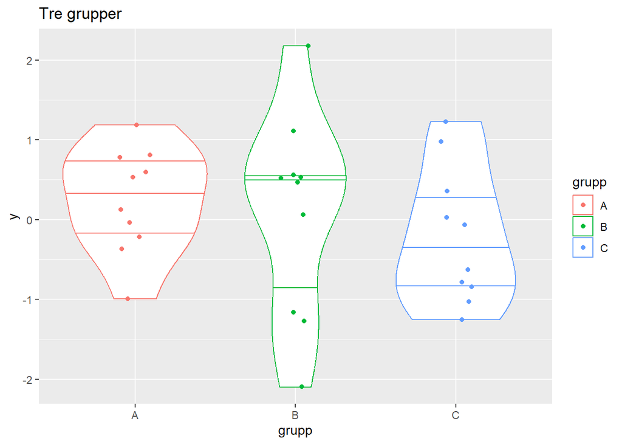

```r
ggplot(df,aes(y=y,x=grupp, col = grupp)) +
  #geom_boxplot() +
  geom_violin(draw_quantiles = c(0.25, 0.5, 0.75)) +
  geom_jitter(width = 0.1) +
  ggtitle("Tre grupper ")
```

## Introduktion av kvadratsummor

Variansanalys tar sin utgångspunkt i att man delar upp variation utifrån var den kommer ifrån. För ensidig variansanalys delar man upp variationen i variation mellan grupper och inom grupper. Detta görs genom att skapa kvadratsummer:

$$SS_{Total} = SS_{Mellan} + SS_{Inom}$$

## Kvadratsumma för total varians

$$SS_{Total} = \sum_{i=1}^{r}\sum_{j=1}^{n_i}(y_{ij}-\bar{y}_{..})^2$$

**Simuleringsexempel (forts.)**

Här beräknar vi kvadratsumman för total varians på två sätt

```r
(n = nrow(df))
```

```
[1] 30
```

```r
(m = mean(df$y))
```

```
[1] 0.04376819
```

```r
(ss_tot = sum((df$y-m)^2))
```

```
[1] 25.81687
```

där vi skattar variansen genom att dela kvadratsumman med lämpligt antal frihetsgrader

```r
ss_tot/(n-1)
```

```
[1] 0.8902369
```

Vi konstaterar att detta ger samma värde som stickprovsvariansen.

```r
var(df$y)
```

```
[1] 0.8902369
```

Vilket betyder att om man känner till den, så kan man härleda kvadratsumman för den totala variationen

```r
var(df$y)*(n-1)
```

```
[1] 25.81687
```

## Kvadratsumma för varians inom grupper

$$SS_{Inom} = \sum_{i=1}^{r}\sum_{j=1}^{n_i}(y_{ij}-\bar{y}_{i.})^2 = \sum_{j=1}^{n_1} (y_{1j}-\bar{y}_{1.})^2+\sum_{j=1}^{n_2} (y_{2j}-\bar{y}_{2.})^2+\dots \sum_{j=1}^{n_r} (y_{rj}-\bar{y}_{r.})^2$$

**Simuleringsexempel (forts.)**

Här beräknar vi först medelvärden inom grupper

```r
(ma = mean(df$y[df$grupp=="A"]))
```

```
[1] 0.242128
```

```r
(mb = mean(df$y[df$grupp=="B"]))
```

```
[1] 0.09034441
```

```r
(mc = mean(df$y[df$grupp=="C"]))
```

```
[1] -0.2011678
```

därefter kvadratsumman för variation inom grupper som en poolad skattning av variansen

```r
(ss_inom = (sum((df$y[df$grupp=="A"]-ma)^2)+sum((df$y[df$grupp=="B"]-mb)^2)+sum((df$y[df$grupp=="C"]-mc)^2)))
```

```
[1] 24.80177
```

Vi kan skatta variansen genom att dela kvadratsumman med lämpligt antal frihetsgrader

```r
ss_inom/(n-r)
```

```
[1] 0.9185842
```

## Kvadratsumma för varians mellan grupper

$$SS_{Mellan} = \sum_{i=1}^{r} n_i (\bar{y}_{i.}-\bar{y}_{..})^2$$
Ett enkelt sätt att beräkna den sista kvadratsumman är $SS_{Mellan} = SS_{Total}-SS_{Inom}$

**Simuleringsexempel (forts.)**

```r
(ss_mellan = ni[1]*(ma - m)^2 + ni[2]*(mb - m)^2 +ni[3]*(mc - m)^2)
```

```
[1] 1.015096
```

```r
ss_tot - ss_inom
```

```
[1] 1.015096
```

Även här kan vi skatta variansen genom att dela kvadratsumman med lämpligt antal frihetsgrader

```r
ss_mellan/(r-1)
```

```
[1] 0.5075479
```

## Teststorhet

Under $H_0$ att alla grupper har lika väntevärden och därmed lika stor varians inom som mellan grupper är teststorheten $F = \frac{\frac{SS_{Mellan}}{r-1}}{\frac{SS_{Inom}}{n-r}} \sim F(r-1,n-r)$.

**Simuleringsexempel (forts.)**

Vi beräknar teststorheten som

```r
((ss_mellan/(r-1))/(ss_inom/(n-r)))
```

```
[1] 0.5525328
```

Den jämförs med kvantil

```r
qf(1-0.05,r-1,n-r)
```

```
[1] 3.354131
```

$H_0$ kan inte förkastas på vald signifikansnivå 0.05

## Samplingsfördelningen för teststorheten i variansanalys

Låt oss göra hypotetiska upprepade observationer och beräkna teststorheten många gånger.

```r
teststorhet <- replicate(1000,{
r = 3
ni = c(10,10,10)
sigma = 1
mui = c(0,0,0)
i=1
y1 <- rnorm(ni[i],mui[i],sigma)
i=2
y2 <- rnorm(ni[i],mui[i],sigma)
i=3
y3 <- rnorm(ni[i],mui[i],sigma)
df_sim <- data.frame(y = c(y1,y2,y3), grupp = c(rep("A",ni[1]),rep("B",ni[2]),rep("C",ni[3])))
n = nrow(df_sim)
m = mean(df_sim$y)
ss_tot = sum((df_sim$y-m)^2)
ma = mean(df_sim$y[df_sim$grupp=="A"])
mb = mean(df_sim$y[df_sim$grupp=="B"])
mc = mean(df_sim$y[df_sim$grupp=="C"])
ss_inom = (sum((df_sim$y[df$grupp=="A"]-ma)^2)+sum((df_sim$y[df$grupp=="B"]-mb)^2)+sum((df_sim$y[df$grupp=="C"]-mc)^2))
ss_mellan = ss_tot - ss_inom
(ss_mellan/(r-1))/(ss_inom/(n-r))
#mod <- lm(y~grupp,df)
#anova(mod)$`F value`[1]
})
```

Vi gör ett histogram av teststorheter och jämför med en F-fördelning med $r-1$ och $n-r$ frihetsgrader

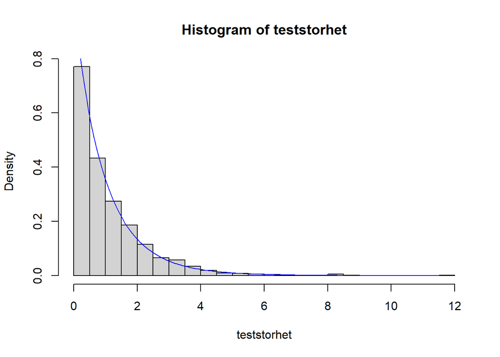

```r
r = 3
n = 30
hist(teststorhet, probability = TRUE, breaks = 20)
ff = seq(0,max(teststorhet),length.out = 200)
dd = df(ff,r-1,n-r)
lines(ff,dd,col='blue')
```

Kvantilen vi jämför med markerar gränsen för det kritiska området där vi ska förkasta nollhypotesen.

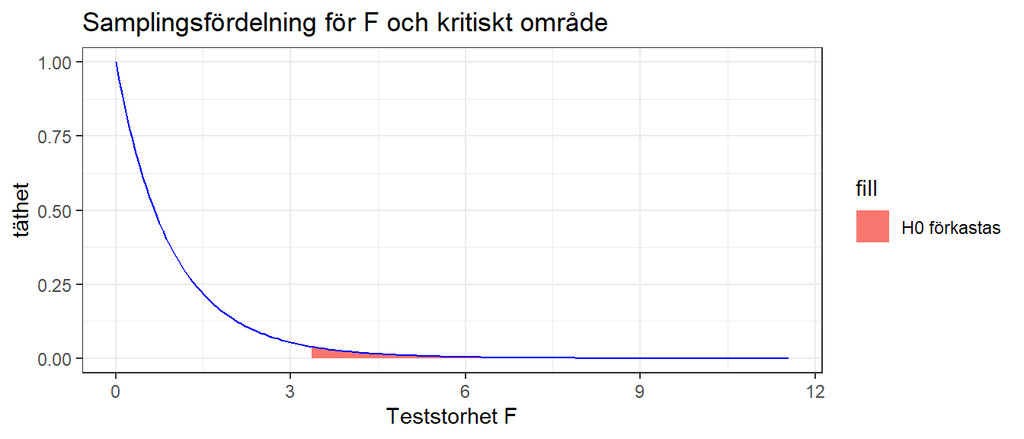

## Variansanalys med statistiskprogram

I R kan man få fram kvadratsummor genom att använda funktionerna `lm` och `anova`. De ger även p-värden för F-testet.

```r
mod <- lm(y~grupp,df)
anova(mod)
```

```
Analysis of Variance Table

Response: y
          Df  Sum Sq Mean Sq F value Pr(>F)
grupp      2  1.0151 0.50755  0.5525 0.5819
Residuals 27 24.8018 0.91858
```

# Variansanalystabell

En ANOVA brukar sammanfattas i en **Variansanalystabell:**

| Källa till variation | Kvadratsumma | frihetsgrader | Medelkvadratsumma |
| --- | --- | --- | --- |
| Mellan grupper | $SS_{Mellan}$ | r-1 | $\frac{SS_{Mellan}}{r-1}$ |
| Inom grupper | $SS_{Inom}$ | n-r | $\frac{SS_{Inom}}{n-r}$ |
| Totalt | $SS_{Total}$ | n-1 | $\frac{SS_{Total}}{n-1}$ |

**Testregel:** (forts.)

Under $H_0$ är $F = \frac{\frac{SS_{Mellan}}{r-1}}{\frac{SS_{Inom}}{n-r}} \sim F(r-1,n-r)$.

Förkasta $H_0$ om $F > F_{\alpha}(r-1,n-r)$

Alternativt, kan man beräkna sannolikheten att teststorheten antar värdet man fick eller värre givet att nollhypotesen är sann - d.v.s. p-värdet.

**Exempel. Urea i musblod**

Ureakoncentrationen i blodet $\mu g/l$ uppmättes vid fyra veckors ålder för möss som uppfötts på tre olika dieter. Resultat för tolv möss (fyra för varje diet) sammanställdes i en tabell.

| Diet |  |  |  |  | $\bar{y}_{i.}$ |
| --- | --- | --- | --- | --- | --- |
| A | 2.9 | 3.9 | 2.5 | 4.3 | 3.4 |
| B | 6.4 | 5.1 | 5.9 | 7.0 | 6.1 |
| C | 10.0 | 8.4 | 9.8 | 11.0 | 9.8 |
|  |  |  |  |  | $\bar{y}_{..} = 6.433$ |

```r
(df <- data.frame(y=c(2.9,3.9,2.5,4.3, 6.4,5.1,5.9,7.0,10.0, 8.4,9.8,11.0),grupp=rep(c("A","B","C"),each = 4)))
```

```
      y grupp
1   2.9     A
2   3.9     A
3   2.5     A
4   4.3     A
5   6.4     B
6   5.1     B
7   5.9     B
8   7.0     B
9  10.0     C
10  8.4     C
11  9.8     C
12 11.0     C
```

```r
df %>%
  group_by(grupp) %>%
  summarise(
    m = mean(y),
    s2 = var(y)
  )
```

```
# A tibble: 3 × 3
  grupp     m    s2
  <chr> <dbl> <dbl>
1 A       3.4 0.707
2 B       6.1 0.647
3 C       9.8 1.15
```

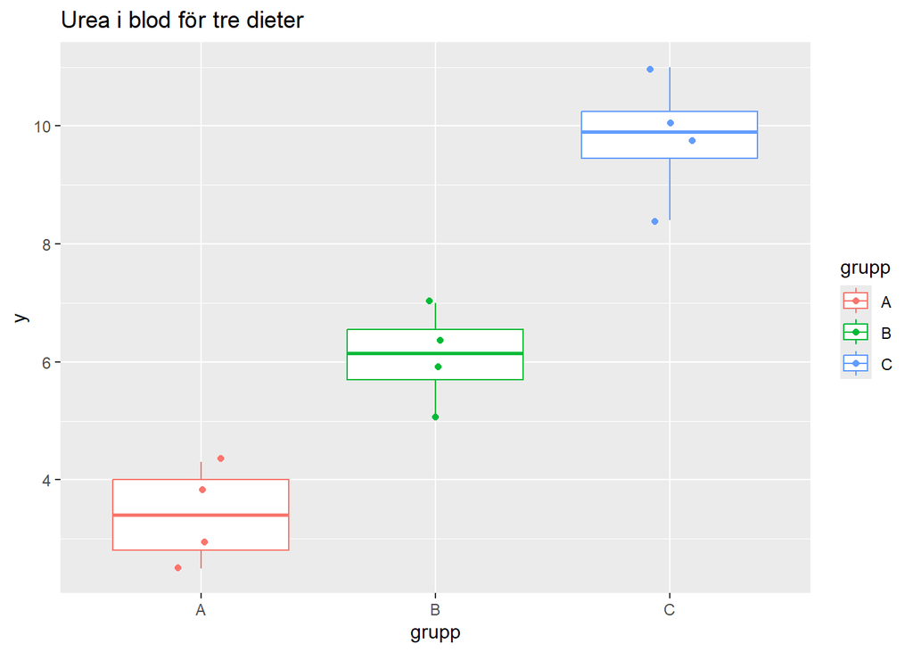

```r
ggplot(df,aes(y=y,x=grupp, col = grupp)) +
  geom_boxplot() +
  geom_jitter(width = 0.1) +
  ggtitle("Urea i blod för tre dieter")
```

**Antagande:** Observationer kommer från normalfördelningar.

**Hypoteser:**

$H_0: \mu_A = \mu_B =\mu_C$ mot $H_1: \text{minst ett väntevärde skiljer sig åt}$

Testas på en signifikansnivå $\alpha = 0.05$

| Källa till variation | Kvadratsumma | frihetsgrader | Medelkvadratsumma |
| --- | --- | --- | --- |
| Mellan grupper | 82.587 | 3-1 = 2 | 41.29 |
| Inom grupper | 7.500 | 12-3 = 9 | 0.83 |
| Totalt | 90.08667 | 12-1 = 11 |  |

$F = \frac{\frac{SS_{Mellan}}{r-1}}{\frac{SS_{Inom}}{n-r}} = \frac{41.29}{0.83} = 49.55$

$H_0$ förkastas eftersom $F > F_{0.05}(2,9) = 4.26$

Slutsatsen är att det finns en skillnad mellan den förväntade mängden urea mellan de tre dieterna.

# Variansanalys är regression med kategoriska förklarande variabler

$y_{ij} = \mu + \alpha_i + \varepsilon_{ij}$ där $\varepsilon_{ij} \sim N(0,\sigma)$

$\alpha_i$ är grupp-specifik fix effekt

```r
mod <- lm(y ~ grupp,data=df)
summary(mod)
```

```
Call:
lm(formula = y ~ grupp, data = df)

Residuals:
   Min     1Q Median     3Q    Max
  -1.4   -0.6    0.1    0.6    1.2

Coefficients:
            Estimate Std. Error t value Pr(>|t|)
(Intercept)   3.4000     0.4564   7.449 3.90e-05 ***
gruppB        2.7000     0.6455   4.183  0.00237 **
gruppC        6.4000     0.6455   9.915 3.84e-06 ***
---
Signif. codes:  0 '***' 0.001 '**' 0.01 '*' 0.05 '.' 0.1 ' ' 1

Residual standard error: 0.9129 on 9 degrees of freedom
Multiple R-squared:  0.9167,    Adjusted R-squared:  0.8982
F-statistic: 49.55 on 2 and 9 DF,  p-value: 1.386e-05
```

```r
anova(mod)
```

```
Analysis of Variance Table

Response: y
          Df Sum Sq Mean Sq F value    Pr(>F)
grupp      2 82.587  41.293  49.552 1.386e-05 ***
Residuals  9  7.500   0.833
---
Signif. codes:  0 '***' 0.001 '**' 0.01 '*' 0.05 '.' 0.1 ' ' 1
```

## Visualisera skattade väntevärden för grupper

```r
(EMM.source <- emmeans(mod, "grupp"))
```

```
 grupp emmean    SE df lower.CL upper.CL
 A        3.4 0.456  9     2.37     4.43
 B        6.1 0.456  9     5.07     7.13
 C        9.8 0.456  9     8.77    10.83

Confidence level used: 0.95
```

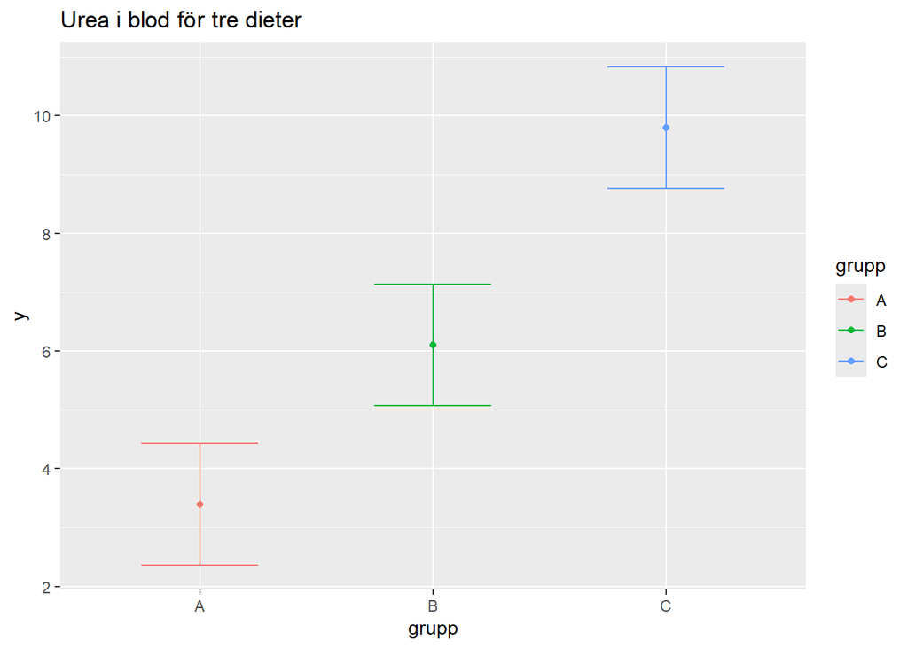

```r
ggplot(data.frame(EMM.source),aes(y=emmean,x=grupp, col = grupp)) +
  geom_point() +
  geom_errorbar(aes(ymin=lower.CL, ymax=upper.CL, width = 0.5)) +
  ggtitle("Urea i blod för tre dieter") +
  ylab("y")
```

## Fortsatta tester

Om nollhypotesen om lika väntvärden förkastas, kan man gå vidare och undersöka mellan vilka grupper det finns en skillnad. Det finns flertalet tester för detta.

Ett exempel är Tukeys test som används när man har lika många observationer i varje grupp. Detta test bildar konfidensintervall för alla parvisa skillnader, men delar upp signifikansnivån mellan paren där den totala konfidensgraden för intervallen är 95%.

```r
TukeyHSD(aov(mod), conf.level=.95)
```

```
  Tukey multiple comparisons of means
    95% family-wise confidence level

Fit: aov(formula = mod)

$grupp
    diff       lwr      upr     p adj
B-A  2.7 0.8977681 4.502232 0.0060127
C-A  6.4 4.5977681 8.202232 0.0000103
C-B  3.7 1.8977681 5.502232 0.0007387
```

> Det är god sed att anpassa signifikansnivå till hur många test man gör, så kallad korrektion för multipla tester.

# Mer om regression

## Logistisk regression

När man har observationer som är 0 eller 1 kan man formulera en modell där responsen är logaritmen av odds-kvoten

$$log(\frac{P(Y_i = 1)}{P(Y_i=0)}) = \beta_0 + \beta_1 x_i$$

## Generaliserade modeller

I denna kurs är responsvariabeln kontinuerlig. Vi kan skriva enkel linjär regression som

$$Y_i\sim N(\beta_0 + \beta_1 x_i, \sigma)$$

Det är vanligt att man har observationer som är diskreta eller kategoriska variabler. Då är det lämpligt att använda generaliserade modeller för regression.

- Poissonregression - när man har observationer som är ett räknat antal

$$Y_i\sim Po(\mu_i)$$
där $log(\mu_i) = \beta_0+\beta_1 x_i$

Det finns flera möjliga val av sannolikhetsfördelning för responsvariabeln (ex $Po$) och val av funktion för att länka väntevärdet $\mu_i$ till en linjär prediktor $\beta_0+\beta_1 x_i$.

Parametrar skattas vanligtvis som de värden som maximerar sannolikheten för observationerna (data) enligt modellen (på engelska *maximum likelihood*), i en del fall genom minska kvadratmetoden (*OLS*) eller med *Bayesiansk inferens*.

## Icke-linjära modeller

Icke-linjära modeller används när det finns anledning att misstänka att sambandet ser ut på ett visst sätt, exempelvis ökar upp till en viss nivå.

## Hierariska modeller

Det kan vara lämpligt att ange flera källor till variation i mätvärden. Hierarkiska modeller innehåller mer än en källa till slumpmässig variation.

I enkel linjär regression har vi en variansterm

$$y_i = \beta_0 + \beta_1 x_i + \varepsilon_i$$
där $\varepsilon_i \sim N(0,\sigma)$

Till exempel skulle mävärden vara insamlade från olika lokaler som har olika intercept

$$y_{is} = \beta_s + \beta_1 x_i + \varepsilon_i$$
där $\beta_s \sim N(0,\sigma_s)$ och $\varepsilon_i \sim N(0,\sigma_\varepsilon)$

Interceptet $\beta_s$ har nu is sig själv en egen slumpmässig variation som beror på grupp $s$ och kallas för en slumpmässig effect (på engelska *random effect*).

Lutningen $\beta_1$ är en fix effekt som är densamma oberoende av lokal.

En modell av detta slag kallas för linjär mixad modell.